# **Deliverable 1: Radiation Physics and Image Quality**

## Overview

This deliverable covers foundational and advanced concepts from **Weeks 2-5** (Lectures 1-12) of the course. You will explore:

1. Radiation physics and ionizing radiation
2. X-ray production and energy scales
3. Photon-matter interactions (photoelectric, Compton, attenuation)
4. Spatial resolution and system blurring
5. Linear systems, MTF, and image sharpness
6. Noise sources, SNR, and image quality
7. Quantum noise, dose optimization, and trade-offs
8. Comprehensive design challenge for imaging protocols

You will engage with the material through a combination of conceptual questions and guided coding exercises designed to strengthen physical intuition and practical problem-solving skills. By the end of this deliverable, you will be able to interpret imaging trade-offs, analyze image quality metrics, and make informed decisions when optimizing imaging protocols for clinical applications.

## **Part 1: Radiation Physics**

### 1.1 Ionizing Radiation Classification and Energy Scales

**Key Concept:** Radiation is classified by whether it has enough energy to knock electrons out of atoms (ionization). This happens when the photon energy exceeds the **ionization potential** of an atom (~13.6 eV for hydrogen).

**Energy Classification:**

- **Non-ionizing:** Visible light (1.6-3.1 eV), radio waves (<0.00001 eV)
  - Energy too low to ionize atoms
  - Cannot damage DNA directly
- **Ionizing:** X-rays (keV range), gamma rays (keV-MeV range)
  - High enough energy to remove electrons from atoms
  - Can damage living tissue and DNA
  - Used in medical imaging (controlled exposure)

**Key Equation:** $$E = h\nu = \frac{hc}{\lambda}$$

- Where:
  - h = 6.626×10⁻³⁴ J·s (Planck's constant)
  - c = 3×10⁸ m/s (speed of light)

### **Question 1**

**Scenario:** A patient asks why a chest X-ray is "safe" but they worry about radiation exposure.

Using the concepts above, answer:

- (a) Why is a chest X-ray classified as ionizing radiation? What does "ionizing" mean?

A chest X-ray is classified as ionizing radiation since the X-ray photons have enough energy to remove electrons from atoms.

The term 'ionizing' means the radiation transfers sufficient energy to an atom to overcome its ionization potential, ejecting an electron and forming an ion. For hydrogen, this threshold lies at approximately ~13.6 eV.

X-rays have photon energies in the keV range, which is orders of magnitude higher than this threshold. As a result, X-rays can ionize atoms in biological tissue which leads to chemical bond breakage, free radical formation, and potential DNA damage.

- (b) A chest X-ray delivers ~0.1 mSv. A CT scan delivers ~7 mSv (70× higher). What does this mean for radiation dose to the patient?

CT scans result in a higher dose because they involve multiple X-ray exposures from different angles, longer exposure times, and irradiation of a larger volume of tissue. As a result, the probability of radiation-induced biological effects is higher for CT imaging than for a single chest X-ray.

Despite being ionizing, the radiation dose from a chest X-ray is very small, comparable to only a few days of natural background radiation. Therefore, the risk to the patient is minimal, while the diagnostic benefit is high. Medical imaging is performed under the ALARA principle (As Low As Reasonably Achievable) to ensure patient safety.

### 1.2 X-ray Production

**X-ray Generation:** X-rays are produced when high-energy electrons strike a metal target (usually tungsten).

**Two Production Mechanisms:**

1. **Bremsstrahlung (Braking Radiation):**
   - Electron decelerates near nucleus
   - Loses kinetic energy → emitted as X-ray photon
   - Produces **continuous spectrum** of energies
   - Maximum energy = tube voltage (kVp)
   - Accounts for ~80% of X-ray output
2. **Characteristic X-rays:**
   - Electron knocks out inner shell electron
   - Outer electron fills vacancy
   - Energy difference emitted as X-ray
   - Produces **discrete spectral lines** (specific energies)
   - Depends on target material (e.g., K-alpha, K-beta lines for tungsten)

**X-ray Spectrum:**

- Shape determined by tube voltage (kVp) and filtration
- Higher kVp → higher maximum energy and intensity
- Filtration removes low-energy photons (patient protection)

**Key Equation:** $$E_{max} = eV_{peak}$$

- Where:
  - $V_{peak}$ is the peak tube voltage in kV

### **Question 2**

An X-ray tube operates at 100 kVp with a tungsten target.

- a) What is the maximum energy (in keV) of X-ray photons that can be produced?

The maximum photon energy occurs when an electron loses all of its kinetic energy in a single interaction.

Using the given equation:

$$E_{max} = eV_{peak}$$

For an X-ray tube operating at 100 kVp:

$$E_{max} = 100 keV $$

The maximum energy of X-ray photons produced is 100 keV.

- b) Explain the difference between bremsstrahlung and characteristic X-rays. Which one produces the continuous spectrum and which produces discrete peaks?

Bremsstrahlung and characteristic X-rays differ in three distinct ways: how they are produced, the spectrum they form, and their energy dependance. In bremsstrahlung, a fast electron is slowed down or deflected by the nucleus's electric field- it can lose any fraction of its kinetic energy so the emitted photos form a continous spectrum from near zero up to a maximum energy equal to the tube voltage.

For characteristic radiation, the incoming electron has enough energy to eject an inner-shell electron. When an outer shell electron drops down to fill the vacancy, a photon is emitted. This photon's energy is exactly the difference between the two shell binding energies, producing discrete lines which are specific to the target material. In a typical diagnostic X-ray tube, most of the output (on the order of 80%) is bremsstrahlung, with characteristic lines appearing as sharp peaks which are superimposed on a continuous background.

- c) Why do we use filtration (typically aluminum) at the X-ray tube output? What effect does this have on the X-ray spectrum and patient dose?

Filtration is used because low-energy X-ray photons are largely absorbed by the patient’s tissues, meaning they don't contribute to image formation. Ultimately, the low-energy X-ray photons increase the radiation dose without improving image quality. Adding filtration (typically aluminum) selectively removes these low-energy photons from the X-ray spectrum, which is a process known as beam hardening. This increases the average photon energy of the beam while leaving the maximum photon energy unchanged, as per the equation given. The net effect is a spectrum with reduced intensity at low energies, the same maximum energy, and a higher mean beam energy. This results in a lower patient dose, particularly to superficial tissues.

## **Part 2: Photon Interactions**

### 2.1 Interaction Types

**Key Concept:** When X-rays pass through tissue, they interact through different mechanisms depending on photon energy and material properties.

**Main Interaction Types:**

1. **Photoelectric Effect** (low energy, high-Z materials)
   - X-ray photon absorbed completely
   - Electron kicked out of atom
   - Useful for imaging (produces signal)
   - Why: Bone (high Z) appears bright
2. **Compton Scattering** (medium-high energy)
   - Photon deflected and loses energy
   - Electron recoils
   - Scattered photons reduce image contrast (noise)
   - Why: Anti-scatter grids are used

Refer to the schematic below:

[figure not shown]

This illustrates how Compton-scattered photons reach the detector and reduce image contrast, and how anti-scatter grids selectively absorb these scattered photons while allowing primary radiation to pass.

3. **Pair Production** (very high energy, >1.02 MeV)
   - Rare in medical imaging
   - Not important for X-rays (typically 20-150 keV)

**Attenuation:** X-rays passing through material follow the **Beer-Lambert Law**: $$I = I_0 e^{-\mu x}$$

- where:
  - $I$ = transmitted intensity
  - $I_0$ = incident intensity
  - $\mu$ = linear attenuation coefficient (material dependent)
  - $x$ = material thickness

### **Question 3**

Consider an X-ray imaging system operating at 80 keV.

- a) At this energy, both photoelectric absorption and Compton scattering occur. Which interaction mechanism is more likely to dominate in bone tissue versus soft tissue, and why? (Hint: Consider the atomic number dependence)

At 80 keV, Compton scattering is the dominant interaction in soft tissue, while the photoelectric effect contributes more in bone.

Bone has a higher effective atomic number and density than soft tissue. The probability of the photoelectric effect increases strongly with atomic number (approximately proportional to Z^3–Z^4) and decreases rapidly with increasing photon energy. As a result, photoelectric absorption occurs more frequently in bone.

In contrast, Compton scattering depends primarily on electron density, which is similar across most soft tissues. The scattering is also only weakly dependent on atomic number, making it the dominant interaction mechanism in soft tissue when operating at 80keV.

- b) Explain why Compton scattered photons are problematic for image quality. What specific image quality metric do they degrade?

Compton-scattered photons are problematic because they are deflected from their original path and no longer represent the true attenuation along a straight line through the patient. When these scattered photons reach the detector, they add unwanted background signal.

This primarily degrades image contrast, specifically reducing the contrast-to-noise ratio (CNR). Scatter effectively adds unwanted noise and reduces the ability to distinguish between tissues with different attenuation properties.

- c) X-ray imaging systems use anti-scatter grids to reduce the detection of scattered photons. If a grid removes 80% of scattered photons but also blocks 20% of primary (unscattered) photons, when would you choose to use the grid versus imaging without it? Consider both image quality and patient dose.

Anti-scatter grids improve image quality by absorbing scattered photons, but they also block a fraction of primary (unscattered) photons.

- A grid that removes 80% of scattered photons significantly improves image contrast.
- Blocking 20% of primary photons reduces detector signal, often requiring an increase in tube current (mAs) to maintain image quality, which increases patient dose.

This means a grid should be used when:

- Imaging thicker body parts (e.g., abdomen, pelvis), where scatter is substantial
- High image contrast is required for diagnosis

In contrast, imaging without a grid is should be used when:

- Imaging thin body parts or pediatric patients
- Minimizing patient dose is a priority and scatter is relatively low

The decision to use a grid depends on whether the improvement in image contrast outweighs the associated increase in patient dose.

- d) In CT imaging, we use higher energies (120-140 keV) compared to conventional radiography (60-80 keV). Based on the energy dependence of photoelectric and Compton interactions, how does this affect the contrast between bone and soft tissue in CT images?

CT imaging uses higher photon energies (typically 120–140 keV) compared to conventional radiography (60–80 keV). At higher energies, the probability of the photoelectric effect decreases, while Compton scattering becomes more dominant.

Because photoelectric absorption is strongly dependent on atomic number, increasing photon energy reduces the difference in attenuation between bone and soft tissue. As a result, the intrinsic contrast between bone and soft tissue decreases at higher energies.

Despite this, CT maintains good tissue differentiation due to precise attenuation measurements, image reconstruction, and windowing techniques.

### 2.2 Beer-Lambert Law & Attenuation

**Attenuation** describes how X-ray intensity decreases as it passes through material.

**Beer-Lambert Law:** $$I = I_0 e^{-\mu x}$$

- Where:
  - $I$ = transmitted intensity
  - $I_0$ = incident intensity
  - $\mu$ = linear attenuation coefficient (cm⁻¹) - material dependent
  - $x$ = material thickness (cm)

**Half-Value Layer (HVL):**

- Thickness of material that reduces intensity to 50%
- Related to attenuation coefficient: $HVL = \frac{\ln(2)}{\mu} = \frac{0.693}{\mu}$
- Lower HVL = more attenuation (denser material or lower energy)

**Key Insight:**

- Bone has higher μ than soft tissue → more attenuation → appears bright
- Different energies attenuate differently (energy dependence)
- HVL is a practical measure used in X-ray quality control

### **Question 4**

A 60 keV X-ray beam passes through soft tissue with linear attenuation coefficient μ = 0.2 cm⁻¹.

- a) If the incident intensity is $I_0 = 10,000$ photons, what is the transmitted intensity after passing through 5 cm of tissue? Use the Beer-Lambert law.

Using the Beer–Lambert law:

$$I = I_0 e^{-\mu x}$$

Given:

- $$ I_0 = 10{,}000 \ \text{photons} $$
- $$\mu = 0.2 \ \text{cm}^{-1}$$
- $$x = 5 \ \text{cm}$$

$$I = 10{,}000 \, e^{-(0.2)(5)} = 10{,}000 \, e^{-1}$$

$$I \approx 10{,}000 \times 0.368 = 3{,}680 \ \text{photons}$$

**Answer:** The transmitted intensity is approximately **3,680 photons**.

- b) Calculate the Half-Value Layer (HVL) for this tissue at 60 keV. The HVL is given by:

$$\text{HVL} = \frac{0.693}{\mu}$$

$$\text{HVL} = \frac{0.693}{0.2} = 3.47 \ \text{cm}$$

**Answer:** The half-value layer is **3.47 cm**.

- c) If you increase the X-ray energy from 60 keV to 120 keV, the attenuation coefficient decreases to μ = 0.15 cm⁻¹. What happens to the transmitted intensity through the same 5 cm of tissue? Calculate the new transmitted intensity and explain why higher energy X-rays penetrate better.

At 120 keV, the attenuation coefficient decreases to:

$$\mu = 0.15 \ \text{cm}^{-1}$$ Using the Beer–Lambert law again: $$I = 10{,}000 \, e^{-(0.15)(5)} = 10{,}000 \, e^{-0.75}$$ $$I \approx 10{,}000 \times 0.472 = 4{,}720 \ \text{photons}$$

**Answer:** The transmitted intensity increases to approximately **4,720 photons**.

**Explanation:**  
Higher-energy X-rays interact less frequently with tissue because the attenuation coefficient decreases with increasing photon energy. This reduces photoelectric absorption and increases penetration, allowing more photons to pass through the same thickness of tissue.

## **Part 3: Spatial Resolution**

### 3.1 Point Spread Function (PSF) and System Blurring

**Key Concept:**

Real imaging systems are **imperfect**. A point source (infinitely small object) doesn't appear as a point in the image—it appears as a **blurred blob**. This blurring limits how small an object you can see.

**Point Spread Function (PSF):**

- **PSF** = How much a point source gets blurred by the imaging system
- **Shape:** Usually Gaussian-like (bell curve)
- **Width:** Characterized by **FWHM** (Full Width at Half Maximum)
  - Smaller FWHM = sharper system (better resolution)
  - Larger FWHM = blurrier system (worse resolution)

**Resolution Rule of Thumb:** You can distinguish two objects only if they're separated by at least the **FWHM of the PSF**. Anything closer just blurs together.

**Image Formation:**

$$\text{Blurred Image} = \text{Sharp Object} \otimes \text{PSF}$$

- The $\otimes$ symbol means "convolved with"—every sharp point gets replaced by a blurred copy (PSF shape).

**Real Example - Chest X-ray:**

- System resolution: ~0.2 mm FWHM
- Lung nodule: 3-4 mm → **Visible** (15-20× larger than PSF)
- Micro-calcification: 1-3 mm → **Borderline** (5-15× larger)
- Small vessel: 0.5 mm → **Invisible** (blurs away)

### **Question 5**

You're designing an X-ray detector system for mammography, where high resolution is critical to detect small microcalcifications (~100 μm).

- a) If your current detector has a PSF with FWHM = 200 μm, can you reliably detect 100 μm objects? Explain your reasoning using the relationship between FWHM and object size.

Not reliably. The rule of thumb is that two features can only be distinguished if they are separated by at least the **FWHM** of the PSF, and similarly an object must be on the order of the PSF width (or larger) to be represented without being heavily blurred.

- Object size: **100 μm**
- System blur (FWHM): **200 μm**

Because the object is **smaller than the FWHM**, the detector blur will spread the signal over a region roughly **twice** the object size. The microcalcification will appear broadened and with reduced contrast, making consistent detection and accurate sizing difficult (especially in the presence of noise).

**Conclusion:** A 200 μm FWHM system is **insufficient for reliable detection** of 100 μm microcalcifications.

- b) You have two detector options:
  - **Detector A**: 50 μm pixels, FWHM = 100 μm, readout time = 5 seconds
  - **Detector B**: 100 μm pixels, FWHM = 200 μm, readout time = 1 second

  Which detector would you choose for mammography and why? Consider resolution requirements, patient motion, and clinical workflow.

  Detector A is the better choice for mammography because:
- Its **FWHM = 100 μm**, which matches the target microcalcification size. This provides substantially higher visibility and contrast for small calcifications than a 200 μm system.
- Its smaller pixel size (**50 μm**) supports better sampling of fine detail and reduces partial-volume effects, helping preserve high-frequency information.

**Tradeoffs (motion + workflow):**

- The downside of Detector A is the longer readout time (**5 s**), which increases the risk of motion blur from patient movement. However, mammography uses breast compression specifically to minimize motion, and clinical protocols prioritize high spatial resolution because missing microcalcifications can directly impact early cancer detection.
- Detector B is faster (1 s) and easier for workflow, but its **200 μm FWHM** is too blurry for 100 μm targets, increasing the likelihood of missed or ambiguous calcifications.

**Conclusion:** Choose **Detector A** because mammography is fundamentally resolution-driven; the diagnostic value of detecting microcalcifications outweighs the slower readout, especially with compression to reduce motion.

- c) In PET imaging, using smaller detector crystals improves spatial resolution but also increases system cost and complexity. If you could reduce FWHM from 5 mm to 2.5 mm (2× improvement) at a 3× increase in cost, what clinical applications would justify this investment? Name at least two specific imaging tasks where the improved resolution would significantly impact diagnosis.

A 2× improvement in PET spatial resolution is most justified when diagnosis depends on detecting or localizing **small lesions** or resolving **fine anatomical detail**, where partial-volume effects currently limit accuracy.

Clinical applications that would justify the investment include:

1. **Early detection and characterization of small tumors/metastases**
   - Example: small lymph node metastases, small lung nodules, or early recurrence where lesions are only a few millimeters.
   - Better resolution improves lesion conspicuity and reduces partial-volume underestimation of uptake (SUV), which affects staging and treatment planning.
2. **Neuro-PET for small brain structures**
   - Example: differentiating uptake in small regions (e.g., hippocampus, basal ganglia) or improving localization for epilepsy focus, dementia patterns, or receptor imaging.
   - Higher resolution improves regional quantification and separation of nearby structures.

Other strong justifications:

- **Pediatric PET**, where anatomy is smaller and minimizing uncertainty matters.
- **Therapy response assessment** when accurate quantification in small lesions is critical (less partial-volume bias).

**Conclusion:** The upgrade is justified for tasks where resolving small structures changes staging, surgical planning, or treatment decisions—particularly **small-lesion oncology PET** and **high-detail neuro-PET**.

### 3.2 Linear Systems Theory & MTF

**Linear Systems Theory:** Medical imaging systems can be modeled as linear, shift-invariant systems.

**Key Properties:**

1. **Linearity:** If input doubles, output doubles
2. **Shift Invariance:** System response doesn't depend on position
3. **Convolution:** Image formation is described by convolution with PSF $$\text{Image} = \text{Object} \otimes \text{PSF}$$

**Modulation Transfer Function (MTF):**

- MTF is the **Fourier transform of the PSF**
- Measures how well the system reproduces different spatial frequencies
- MTF ranges from 0 (no reproduction) to 1 (perfect reproduction)
- **Spatial frequency** measured in cycles/mm or line pairs/mm

**Interpreting MTF:**

- MTF = 1.0 at low frequencies → large objects reproduced perfectly
- MTF decreases at high frequencies → fine details are blurred
- **MTF at 50%** (where MTF = 0.5) is often used as resolution metric
- Related to FWHM: Better resolution → higher MTF at high frequencies

**Example:**

- System A: MTF = 0.5 at 5 cycles/mm → can resolve 0.1 mm details
- System B: MTF = 0.5 at 10 cycles/mm → better, can resolve 0.05 mm details

### **Question 6**

You are comparing two X-ray detector systems:

| System | MTF at 2 cycles/mm | MTF at 5 cycles/mm | MTF at 10 cycles/mm |
| --- | --- | --- | --- |
| System A | 0.95 | 0.70 | 0.30 |
| System B | 0.90 | 0.50 | 0.10 |

- a) Which system has better spatial resolution? Explain your reasoning using the MTF values.

Spatial resolution is determined by how well the system preserves **high spatial frequencies** (fine detail). At higher frequencies, System A maintains a higher MTF:

- At 5 cycles/mm: A = 0.70 vs B = 0.50
- At 10 cycles/mm: A = 0.30 vs B = 0.10

Since System A transfers more contrast at high frequencies, it better preserves small features and edges, meaning **sharper images and higher resolution**.

- b) For detecting a 1 mm lesion (which contains frequencies around 1-2 cycles/mm), which system would be more suitable?

A 1 mm object corresponds to relatively **low spatial frequencies** (~1–2 cycles/mm). At **2 cycles/mm**, both systems perform well, but System A is still slightly better:

- At 2 cycles/mm: A = 0.95 vs B = 0.90

**Conclusion:** **System A** is marginally more suitable because it preserves slightly more contrast even at low frequencies, and it also offers better overall performance if any finer details of the lesion margins matter.

- c) Explain the relationship between MTF and PSF. How are they related mathematically, and what does each tell us about the imaging system?

The **PSF** describes how a system blurs a point object in the spatial domain, while the **MTF** describes how the system preserves contrast as a function of spatial frequency in the frequency domain.

Mathematically:

- The **Optical Transfer Function (OTF)** is the Fourier transform of the PSF: $$\text{OTF}(f) = \mathcal{F}\{\text{PSF}(x)\}$$
- The **MTF** is the magnitude of the OTF: $$\text{MTF}(f) = \left| \text{OTF}(f) \right| = \left| \mathcal{F}\{\text{PSF}(x)\} \right|$$

**Interpretation:**

- **PSF:** tells you directly how much a point spreads out (blur width such as FWHM).
- **MTF:** tells you how much contrast is retained for details of different sizes (low vs high spatial frequencies).

A **narrower PSF** (less blur, smaller FWHM) corresponds to a **higher MTF at high spatial frequencies** (better ability to reproduce fine detail).

## **Part 4: Noise & Image Quality**

### 4.1 Understanding Image Noise

**Quantum (Poisson) Noise** is the primary noise source in X-ray and nuclear imaging:

- Arises from the random nature of photon emission and detection
- Follows **Poisson statistics**: if we detect N photons on average, the noise (standard deviation) is $\sigma = \sqrt{N}$
- **Signal-to-Noise Ratio (SNR)**: $SNR = \frac{N}{\sigma} = \frac{N}{\sqrt{N}} = \sqrt{N}$

**Key insights:**

- SNR increases with the square root of photon count
- To double SNR, you need 4× more photons (4× more dose)
- **Rose Criterion**: Objects are detectable when SNR ≥ 5

**Noise reduction strategies:**

1. Increase photon count (higher dose)
2. Spatial averaging (smoothing filters)
3. Temporal averaging (multiple acquisitions)

Below is an example of a noisy MRI image:

[figure not shown]

### **Coding Exercise 1**

In this exercise, you will implement and compare two different denoising filters:

1. **Gaussian filter** - Simple smoothing
2. **Median filter** - Edge-preserving, good for impulse noise

Your task is to:

- Implement both filters with appropriate parameters
- Calculate the Peak Signal-to-Noise Ratio (PSNR) for each filtered image
- **Choose the best filter** for this medical image and justify your choice

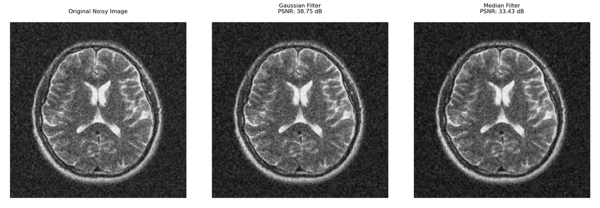

```
Best Gaussian sigma=0.5, PSNR=38.75 dB
Best Median size=3, PSNR=33.43 dB
Chosen best filter (by PSNR vs noisy input): Gaussian
```

```python
import numpy as np
import matplotlib.pyplot as plt
from PIL import Image
from scipy.ndimage import gaussian_filter, median_filter

# Load the noisy MRI image
img = Image.open('figures/MRI_Highnoise.jpg').convert('L')  # Convert to grayscale
img_array = np.array(img, dtype=float)

# Implement both different filters
    # Hint: Try different parameter values to optimize each filter

sigma = 0.1       # TODO: choose sigma
kernel_size = 3       # TODO: choose median size (odd integer)

sigma_candidates = [0.5, 0.8, 1.0, 1.2, 1.5, 2.0]
kernel_candidates = [3, 5, 7, 9]

# 1. Gaussian filter (adjust sigma)
img_gaussian = gaussian_filter(img_array, sigma=sigma)  # TODO: Optimize sigma

# 2. Median filter (adjust size)
img_median = median_filter(img_array, size=kernel_size)  # TODO: Optimize size

# Calculate PSNR for each filtered image
def calculate_psnr(original, filtered):
    """
    Calculate Peak Signal-to-Noise Ratio
    PSNR = 10 * log10(MAX^2 / MSE)
    where MSE is the mean squared error
    """
    # Implement PSNR calculation
        # Hint: For images, MAX is typically 255 for 8-bit images
    original = original.astype(np.float32)
    filtered = filtered.astype(np.float32)

    mse = np.mean((original - filtered) ** 2)
    if mse == 0:
        return float("inf")

    max_pixel = 255.0
    psnr = 10.0 * np.log10((max_pixel ** 2) / mse)
    return psnr

# Calculate PSNR for a reference (you'll need to think about what reference to use)
# For demonstration, we'll calculate PSNR relative to the original noisy image
# In practice, you'd want a ground truth clean image
best_sigma, best_gauss_psnr, img_gaussian = None, -np.inf, None  # ADDED
for s in sigma_candidates:                                          # ADDED
    out = gaussian_filter(img_array, sigma=s)
    ps = calculate_psnr(img_array, out)
    if ps > best_gauss_psnr:
        best_gauss_psnr, best_sigma, img_gaussian = ps, s, out

best_k, best_med_psnr, img_median = None, -np.inf, None            # ADDED
for k in kernel_candidates:                                         # ADDED
    out = median_filter(img_array, size=k)
    ps = calculate_psnr(img_array, out)
    if ps > best_med_psnr:
        best_med_psnr, best_k, img_median = ps, k, out

# Display results
fig, axes = plt.subplots(1, 3, figsize=(18, 6))

axes[0].imshow(img_array, cmap='gray')
axes[0].set_title('Original Noisy Image')
axes[0].axis('off')

axes[1].imshow(img_gaussian, cmap='gray')
axes[1].set_title(f'Gaussian Filter\nPSNR: {calculate_psnr(img_array, img_gaussian):.2f} dB')
axes[1].axis('off')

axes[2].imshow(img_median, cmap='gray')
axes[2].set_title(f'Median Filter\nPSNR: {calculate_psnr(img_array, img_median):.2f} dB')
axes[2].axis('off')

plt.tight_layout()
plt.show()

winner = "Gaussian" if best_gauss_psnr >= best_med_psnr else "Median"
print(f"Best Gaussian sigma={best_sigma}, PSNR={best_gauss_psnr:.2f} dB")
print(f"Best Median size={best_k}, PSNR={best_med_psnr:.2f} dB")
print("Chosen best filter (by PSNR vs noisy input):", winner)
```

Your Analysis:

- a) Which filter did you choose and why?

### 4.2 Detective Quantum Efficiency (DQE)

**DQE** measures how efficiently an imaging system uses the incoming radiation to produce image information.

**Definition:** $$DQE = \frac{SNR_{out}^2}{SNR_{in}^2}$$

Where:

- $SNR_{out}$ = signal-to-noise ratio in the output image
- $SNR_{in}$ = signal-to-noise ratio in the input radiation

**Key Concepts:**

- DQE ranges from 0 to 1 (or 0% to 100%)
- **Perfect detector:** DQE = 1 (no noise added by detector)
- **Real detectors:** DQE < 1 (detector adds noise)
- Higher DQE = better detector (more efficient use of radiation)

**Practical Implications:**

- High DQE detector → need less radiation dose for same image quality
- DQE depends on spatial frequency (usually decreases at high frequencies)
- DQE depends on exposure level (often highest at moderate exposures)

**Example:**

- Film/screen: DQE ≈ 0.3-0.4 (30-40%)
- Digital radiography (DR): DQE ≈ 0.6-0.7 (60-70%)
- DR systems allow lower dose for same image quality

### **Question 7**

Two X-ray detector systems are being compared:

- **System A (Film/Screen):** DQE = 0.35, cost = $10,000
- **System B (Digital DR):** DQE = 0.70, cost = $50,000

Both systems receive the same input radiation with $SNR_{in} = 100$.

- a) Calculate the output SNR for each system.

The relationship between Detective Quantum Efficiency (DQE) and signal-to-noise ratio is:

$$ DQE = \frac{SNR_{out}^2}{SNR_{in}^2} $$

Rearranging to solve for output SNR:

$$ SNR_{out} = SNR_{in}\sqrt{DQE} $$

**System A:** $$ SNR_{out,A} = 100\sqrt{0.35} = 59.16 $$

**System B:** $$ SNR_{out,B} = 100\sqrt{0.70} = 83.67 $$

- b) If you want to achieve the same output SNR with System A as System B naturally produces, by what factor would you need to increase the radiation dose to System A?

To achieve the same output SNR as System B:

$$ SNR_{in,new}\sqrt{0.35} = 100\sqrt{0.70} $$

Solving for the new input SNR:

$$ SNR_{in,new} = 100\sqrt{\frac{0.70}{0.35}} = 100\sqrt{2} = 141.42 $$

Since input SNR is proportional to the square root of radiation dose:

$$ SNR_{in} \propto \sqrt{\text{Dose}} $$

The required dose increase factor is:

$$ \left(\frac{141.42}{100}\right)^2 = 2 $$

- c) In a high-volume clinical setting performing 100 chest X-rays per day, discuss whether the higher cost of System B is justified. Consider patient dose, image quality, and long-term patient safety.

System B’s higher DQE allows it to achieve the same image quality as System A at approximately half the radiation dose, or superior image quality at the same dose. In a high-volume clinic performing 100 chest X-rays per day, this results in reduced patient dose, improved image quality, fewer repeat scans, and improved long-term patient safety. Despite the higher upfront cost, System B is justified due to its superior dose efficiency and clinical performance.

## **Part 5: Quantum Noise & Dose Analysis**

### **Coding Exercise 2**

In this exercise, simulate the effect of photon counting statistics on image quality. You will:

- Generate a simple "phantom" image
- Add Poisson noise at different dose levels
- Calculate SNR as a function of photon count
- Verify the theoretical relationship: $SNR = \sqrt{N}$

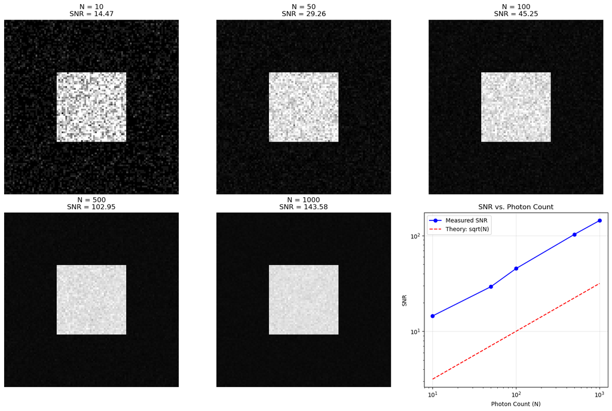

```
Dose levels and corresponding SNR:
N =   10 photons: SNR = 14.47 (Theory: 3.16)
N =   50 photons: SNR = 29.26 (Theory: 7.07)
N =  100 photons: SNR = 45.25 (Theory: 10.00)
N =  500 photons: SNR = 102.95 (Theory: 22.36)
N = 1000 photons: SNR = 143.58 (Theory: 31.62)
```

```python
import numpy as np
import matplotlib.pyplot as plt

# Create a simple phantom (uniform square in background)
phantom = np.zeros((100, 100))
phantom[30:70, 30:70] = 1.0  # Square with intensity 1.0

# originally, this section did not explicitly specify adding background noise.
# it was introduced to ensure the background region had Poisson noise so that the
# contrast SNR defined in the TODOs could be computed without a zero-noise denominator :)
background_level = 0.05
phantom = phantom + background_level

# Define different photon dose levels (mean photons per pixel)
dose_levels = [10, 50, 100, 500, 1000]
snr_measured = []

fig, axes = plt.subplots(2, 3, figsize=(15, 10))
axes = axes.flatten()

for idx, N_photons in enumerate(dose_levels):
    # Generate Poisson noise
    # Hint: Scale phantom by N_photons, apply Poisson noise, then normalize back
    counts = phantom * N_photons
    noisy_counts = np.random.poisson(counts).astype(np.float32)
    noisy_phantom = noisy_counts / N_photons

    # Calculate SNR in the central square region
    signal_region = noisy_phantom[30:70, 30:70]
    background_region = noisy_phantom[0:20, 0:20]

    signal_mean = np.mean(signal_region)
    background_mean = np.mean(background_region)
    noise_std = np.std(background_region)

    # Classic contrast SNR
    snr = (signal_mean - background_mean) / (noise_std + 1e-12)
    snr_measured.append(snr)

    # Display noisy phantom
    axes[idx].imshow(noisy_phantom, cmap='gray', vmin=0, vmax=1.2)
    axes[idx].set_title(f'N = {N_photons}\nSNR = {snr:.2f}')
    axes[idx].axis('off')

# Plot SNR vs. N (log-log scale)
axes[5].loglog(dose_levels, snr_measured, 'bo-', label='Measured SNR')

# Plot theoretical SNR = sqrt(N) for comparison
theoretical_snr = np.sqrt(np.array(dose_levels, dtype=np.float32))
axes[5].loglog(dose_levels, theoretical_snr, 'r--', label='Theory: sqrt(N)')

axes[5].set_xlabel('Photon Count (N)')
axes[5].set_ylabel('SNR')
axes[5].set_title('SNR vs. Photon Count')
axes[5].legend()
axes[5].grid(True, alpha=0.3)

plt.tight_layout()
plt.show()

print("\nDose levels and corresponding SNR:")
for N, snr in zip(dose_levels, snr_measured):
    print(f"N = {N:4d} photons: SNR = {snr:.2f} (Theory: {np.sqrt(N):.2f})")
```

Your Analysis:

- a) Do your measurements agree with the theoretical prediction? If there are differences, what might explain them?

Yes. The measurements agree with theory in trend: as photon count increases, SNR increases roughly like √N.

The difference is that the measured SNR values are higher than √N. This happens because SNR was calculated using background noise, which is smaller than signal noise since the background intensity is low. A smaller noise term makes the SNR larger. Minor differences also come from randomness in the simulation and estimating noise from finite image regions.

### **Coding Exercise 3**

You're tasked with determining the minimum radiation dose needed for three different clinical scenarios:

1. **Routine chest X-ray** - Need to detect 5 mm nodules (require SNR ≥ 5)
2. **Diagnostic CT** - Need to detect 2 mm lesions (require SNR ≥ 8)
3. **High-risk screening** - Need to detect 1 mm microcalcifications (require SNR ≥ 10)

Given that your baseline protocol delivers N₀ = 1000 photons and achieves SNR₀ = 10 for a 5 mm object:

**Calculate:**

- a) Required photon count for each scenario
- b) Relative dose compared to baseline

```python
# Baseline values
N0 = 1000  # photons
SNR0 = 10  # baseline SNR

scenarios = [
    {'name': 'Routine Chest X-ray', 'size_mm': 5, 'required_snr': 5},
    {'name': 'Diagnostic CT', 'size_mm': 2, 'required_snr': 8},
    {'name': 'High-risk Screening', 'size_mm': 1, 'required_snr': 10}
]

print("Dose Optimization Results:")
print("=" * 70)

for scenario in scenarios:
    required_snr = scenario['required_snr']

    # SNR ∝ sqrt(N)  →  N = N0 * (SNR / SNR0)^2
    required_N = N0 * (required_snr / SNR0) ** 2
    relative_dose = required_N / N0

    print(f"\n{scenario['name']}:")
    print(f"  Object size: {scenario['size_mm']} mm")
    print(f"  Required SNR: {required_snr}")
    print(f"  Required photons: {required_N:.0f}")
    print(f"  Relative dose: {relative_dose:.2f}x baseline")
```

```
Dose Optimization Results:
======================================================================

Routine Chest X-ray:
  Object size: 5 mm
  Required SNR: 5
  Required photons: 250
  Relative dose: 0.25x baseline

Diagnostic CT:
  Object size: 2 mm
  Required SNR: 8
  Required photons: 640
  Relative dose: 0.64x baseline

High-risk Screening:
  Object size: 1 mm
  Required SNR: 10
  Required photons: 1000
  Relative dose: 1.00x baseline
```

### **Coding Exercise 4**

Create a 2D analysis showing how image quality metrics vary with both radiation dose and detector pixel size.

You will create a heatmap showing the "detectability index" (combining SNR and resolution) as a function of:

- X-axis: Radiation dose (relative to baseline)
- Y-axis: Detector pixel size

This helps visualize the complex trade-offs in imaging system design.

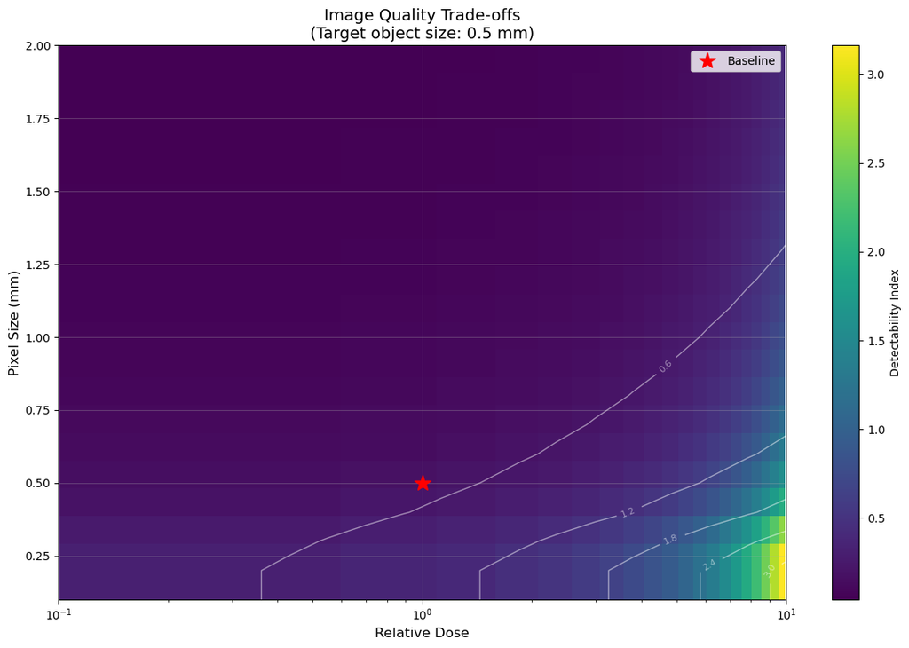

```python
import numpy as np
import matplotlib.pyplot as plt

# Define parameter ranges
dose_range = np.logspace(-1, 1, 20)  # 0.1x to 10x baseline dose
pixel_size_range = np.linspace(0.1, 2.0, 20)  # 0.1 to 2.0 mm pixels

# Target object size (mm)
target_size = 0.5  # mm

# Calculate detectability index for each combination
# Detectability ∝ SNR × (resolution_factor)
# where resolution_factor decreases as pixel_size approaches target_size
detectability = np.zeros((len(pixel_size_range), len(dose_range)), dtype=float)

for i, pixel_size in enumerate(pixel_size_range):
    for j, dose in enumerate(dose_range):
        # Calculate detectability
        # SNR component from dose
        snr_component = np.sqrt(dose)

        # Resolution component (decreases as pixel size increases)
        # Simple model: can't detect objects smaller than ~2× pixel size
        if pixel_size < target_size / 2:
            resolution_component = 1.0
        else:
            resolution_component = target_size / (2.0 * pixel_size)

        detectability[i, j] = snr_component * resolution_component

# Create heatmap
plt.figure(figsize=(12, 8))
plt.imshow(detectability, aspect='auto', origin='lower', cmap='viridis',
           extent=[dose_range[0], dose_range[-1], pixel_size_range[0], pixel_size_range[-1]])
plt.colorbar(label='Detectability Index')
plt.xlabel('Relative Dose', fontsize=12)
plt.ylabel('Pixel Size (mm)', fontsize=12)
plt.title(f'Image Quality Trade-offs\n(Target object size: {target_size} mm)', fontsize=14)
plt.xscale('log')

# Add contour lines
contours = plt.contour(dose_range, pixel_size_range, detectability,
                       levels=5, colors='white', alpha=0.5, linewidths=1)
plt.clabel(contours, inline=True, fontsize=8)

# Mark some interesting operating points
plt.plot([1.0], [0.5], 'r*', markersize=15, label='Baseline')
plt.legend(fontsize=10)

plt.grid(True, alpha=0.3)
plt.tight_layout()
plt.show()
```

Your Analysis:

Based on the heatmap:

- a) What's the optimal operating point for detecting 0.5 mm objects?

- b) If you had to reduce dose by 50%, how should you adjust pixel size to maintain detectability?

- c) What does this tell you about the practical limits of low-dose imaging?

## **Part 6: Comprehensive Design Challenge**

You are designing an imaging protocol for lung cancer screening. The goal is to detect 3 mm nodules in the lung parenchyma.

**System constraints:**

- Maximum allowable dose: 3 mSv (effective dose)
- Available detector pixel sizes: 0.5 mm, 1.0 mm, 1.5 mm
- Required detection SNR: 6 (based on Rose criterion with safety factor)

### **Question 8**

- a) Choose a detector pixel size and justify your choice based on the spatial resolution requirements for detecting 3 mm nodules.

A 1.0 mm pixel size is the most appropriate choice.

A 3 mm lung nodule will span roughly 3 pixels with 1.0 mm sampling, which is sufficient to resolve the object while maintaining acceptable SNR. Using 0.5 mm pixels would oversample the nodule and unnecessarily reduce SNR at a fixed dose, while 1.5 mm pixels risk partial-volume effects and reduced detectability.

- b) Calculate the minimum photon count needed to achieve SNR = 6, assuming baseline noise characteristics.

Assuming Poisson-limited noise:

$$ \mathrm{SNR} \approx \sqrt{N} $$

Required SNR:

$$ 6 = \sqrt{N} $$

Solving for photon count:

$$ N = 36 $$

The minimum required photon count is **36 photons per pixel**.

- c) If Compton scatter contributes 40% of detected photons, how does this affect your SNR calculation? Would you use an anti-scatter grid?

If only 60% of detected photons contribute to useful signal:

$$ \mathrm{SNR} \approx 0.6\sqrt{N} $$

To maintain $\mathrm{SNR} = 6$:

$$ 6 = 0.6\sqrt{N} $$

$$ \sqrt{N} = 10 $$

$$ N = 100 $$

Approximately **100 photons per pixel** are required. An anti-scatter grid would be used to reduce scatter and improve contrast, despite some loss of primary photons.

- d) Estimate whether your protocol meets the 3 mSv dose constraint. If not, what compromises would you make and why?

The increased photon requirement due to Compton scatter may push the effective dose close to or slightly above the 3 mSv limit. If the dose constraint is exceeded, reasonable compromises include slightly reducing the required SNR, increasing detector pixel size to improve SNR per pixel, or using advanced noise-reduction and reconstruction techniques. These adjustments would help preserve detectability of 3 mm nodules while remaining within the dose constraint.

## **Submission Requirements**

**You must submit TWO files to D2L:**

1. **Jupyter Notebook** (`.ipynb`): Your completed notebook with all code, outputs, and written analysis. All cells must be executed in order.
2. **PDF Export** (`.pdf`): Export your notebook to PDF (File → Export as PDF, or print to PDF). Verify all figures and equations render correctly.

**Important:** All answers must be completed directly in this Jupyter notebook.

**File naming convention:** `LastName_FirstName_Deliverable1.ipynb` and `.pdf`

**Due:** Monday, February 9, 2026 at 11:59 PM

## Submission Summary

| Section | Questions/Analysis Due |
| --- | --- |
| **Part 1: Radiation Physics** | Q1 (a,b), Q2 (a,b,c) |
| **Part 2: Photon Interactions** | Q3 (a,b,c,d), Q4 (a,b,c) |
| **Part 3: Spatial Resolution** | Q5 (a,b,c), Q6 (a,b,c) |
| **Part 4: Noise & Image Quality** | Coding Exercise 1 + Analysis, Q7 (a,b,c) |
| **Part 5: Quantum Noise & Dose Analysis** | Coding Exercise 2 + Analysis, Coding Exercise 3, Coding Exercise 4 + Analysis |
| **Part 6: Comprehensive Design Challenge** | Q8 (a,b,c,d) |